# BILGER-HANS-ADA-HOMEWORK-02

Hans Bilger

February 26, 2019

### Challenge #1: Poisson distributions

#### 1.a. What is the probability that she will hear more than 8 calls during any given session?

```r
#We can use the probability mass function for the Poisson distribution to determine this:

e <- 2.71828
fish <- function(l, x) {
  ((l^x * e^(-l)) / factorial(x))
}

fish(15, 8)
```

```
## [1] 0.0194445
```

```r
#or we can also use the functionality built into base R:

dpois(x = 8, lambda = 15)
```

```
## [1] 0.0194443
```

```r
# So, the probability of hearing more than 8 calls in a given session should be:
# P(>8) = 1 - P(<=8) = 1 - (P(0:8))

1 - sum(fish(15, 0:8))
```

```
## [1] 0.9625531
```

```r
# or

1 - sum(dpois(x = 0:8, lambda = 15))
```

```
## [1] 0.9625535
```

```r
# or, using cumulative distribution functions

1- ppois(q = 8, lambda = 15)
```

```
## [1] 0.9625535
```

#### 1.b. What is the probability that she will hear no calls in a session?

```r
fish(15, 0)
```

```
## [1] 3.059054e-07
```

```r
#or

dpois(x = 0, lambda = 15)
```

```
## [1] 3.059023e-07
```

#### 1.c. What is the probability that she will hear exactly 3 calls in a session?

```r
fish(15, 3)
```

```
## [1] 0.0001720718
```

```r
# or

dpois(x = 3, lambda = 15)
```

```
## [1] 0.0001720701
```

#### 1.d. Plot the relevant Poisson mass function over the values in range 0 ≤ x ≤ 30

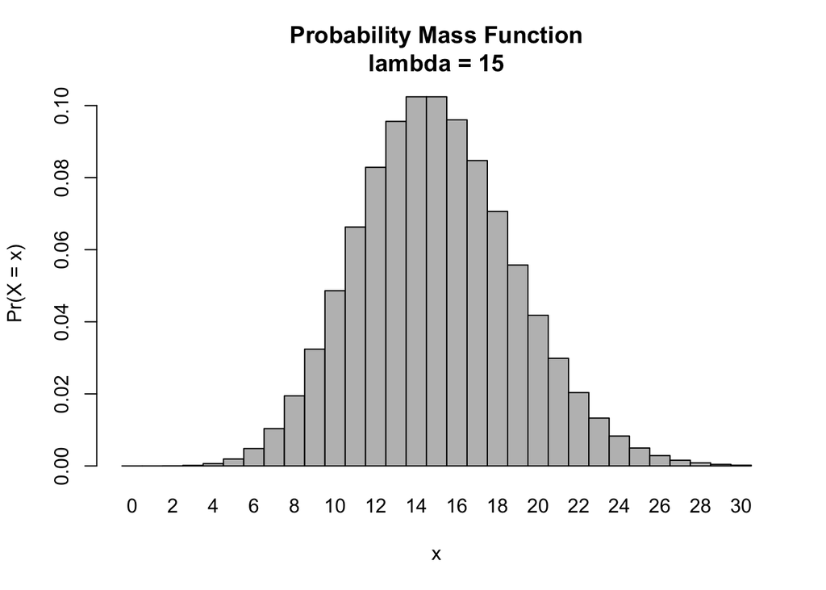

```r
x <- 0:30
l = 15
monkeycalls <- dpois(x = x, lambda = l)
barplot(monkeycalls, names.arg = x, space = 0, xlab = "x", ylab = "Pr(X = x)", main = paste0("Probability Mass Function\nlambda = ",
    l))
```

#### 1.e. Simulate 104 results from this distribution (i.e., 2 years of Saturday monitoring sessions).

```r
TwoYears <- rpois(104, 15)
TwoYears
```

```
##   [1] 11 16  9 13 16 19 14 11 17 21 16 12 15 15 17  8 12 16 15 20 15 15 19
##  [24] 11  7 11 10 12  9 17 18 14 23 11 18 18 10 12 14 14 20 11 12 13 16 14
##  [47]  6 18 17 16 14  9 20 16 12 19 14 13 13 16 15 13 19 11 16 18 17 16 12
##  [70] 13 24  7 13 14 13 13 14 16 13 13 12 15 17 15 18 12 16 11 19 17 15 29
##  [93] 14 17 18 10 19 13 12 17 13 16 13 10
```

#### 1.f. Plot the simulated results using hist() and use xlim() to set the horizontal limits to be from 0 to 30. How does your histogram compare to the shape of the probability mass function you plotted above?

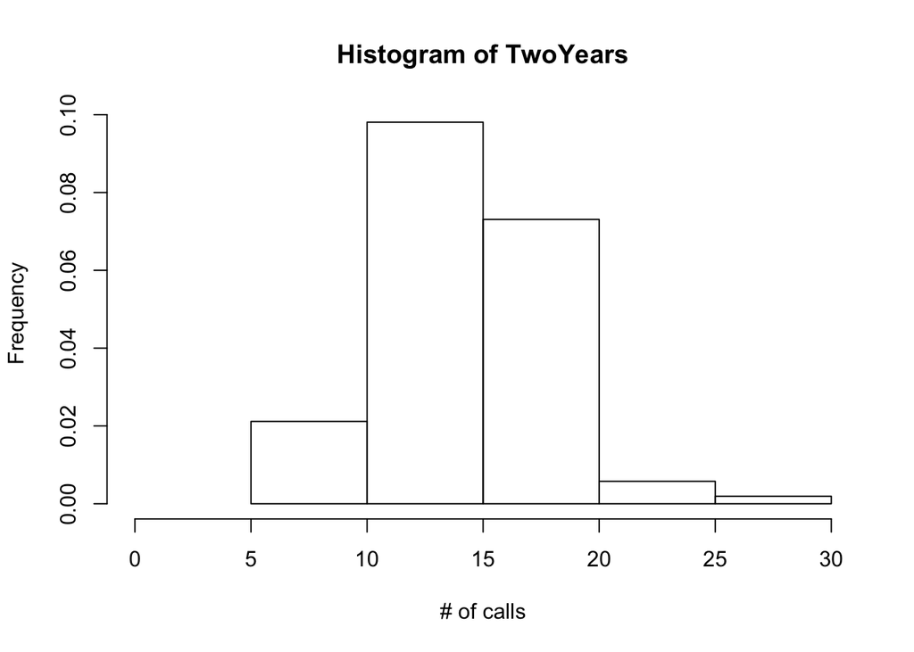

```r
hist(TwoYears, xlim = c(0,30), xlab = "# of calls", ylab = "Frequency", prob = TRUE)
```

```r
# My histogram looks similar to the shape of the probability mass function plotted above, but the shape of the curve is not quite as smooth. It seems to taper off more quickly as the values approach 0. I assume this is in part because the histogram is constructed from fewer observations.
```

# Challenge 2: Zombies

```r
f <- f <- curl("https://raw.githubusercontent.com/difiore/ADA-2019/master/zombies.csv")
d <- read.csv(f, header = TRUE, sep = ",", stringsAsFactors = FALSE)
head(d)
```

```
##   id first_name last_name gender   height   weight zombies_killed
## 1  1      Sarah    Little Female 62.88951 132.0872              2
## 2  2       Mark    Duncan   Male 67.80277 146.3753              5
## 3  3    Brandon     Perez   Male 72.12908 152.9370              1
## 4  4      Roger   Coleman   Male 66.78484 129.7418              5
## 5  5      Tammy    Powell Female 64.71832 132.4265              4
## 6  6    Anthony     Green   Male 71.24326 152.5246              1
##   years_of_education                           major      age
## 1                  1                medicine/nursing 17.64275
## 2                  3 criminal justice administration 22.58951
## 3                  1                       education 21.91276
## 4                  6                  energy studies 18.19058
## 5                  3                       logistics 21.10399
## 6                  4                  energy studies 21.48355
```

#### 2.a. Calculate the population mean and standard deviation for each quantitative random variable (height, weight, age, number of zombies killed, and years of education).

```r
meanHeight <- mean(d$height)
meanHeight
```

```
## [1] 67.6301
```

```r
meanWeight <- mean(d$weight)
meanWeight
```

```
## [1] 143.9075
```

```r
meanAge <- mean(d$age)
meanAge
```

```
## [1] 20.04696
```

```r
meanKilled <- mean(d$zombies_killed)
meanKilled
```

```
## [1] 2.992
```

```r
meanEd <- mean(d$years_of_education)
meanEd
```

```
## [1] 2.996
```

```r
sdHeight <- sqrt(sum((d$height - mean(d$height))^2)/(1000))
sdHeight
```

```
## [1] 4.30797
```

```r
sdWeight <- sqrt(sum((d$weight - mean(d$weight))^2)/(1000))
sdWeight
```

```
## [1] 18.39186
```

```r
sdAge <- sqrt(sum((d$age - mean(d$age))^2)/(1000))
sdAge
```

```
## [1] 2.963583
```

```r
sdKilled <- sqrt(sum((d$zombies_killed - mean(d$zombies_killed))^2)/(1000))
sdKilled
```

```
## [1] 1.747551
```

```r
sdEd <- sqrt(sum((d$years_of_education - mean(d$years_of_education))^2)/(1000))
sdEd
```

```
## [1] 1.675704
```

#### 2.b. Use {ggplot} and make boxplots of each of these variable by gender.

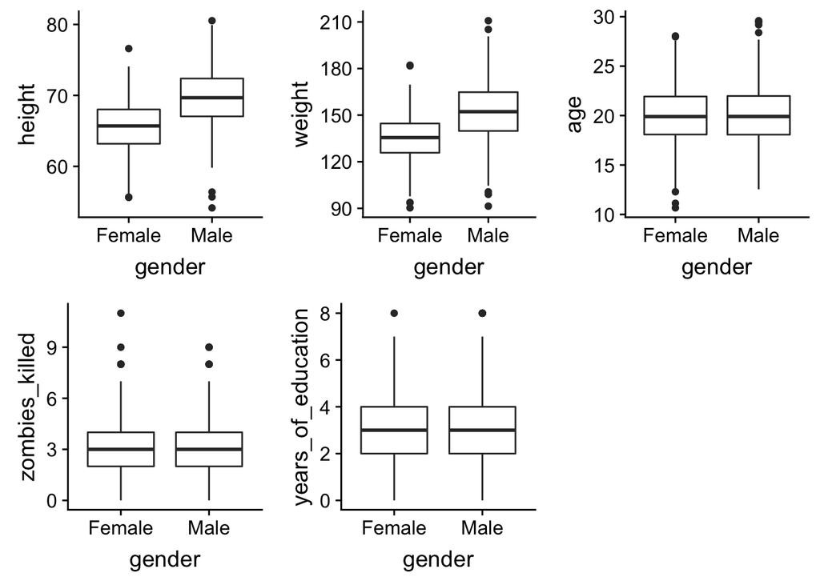

```r
# mean boxplots
HeightBP <- ggplot(d, aes(x=gender, y=height)) +
  geom_boxplot()

WeightBP <- ggplot(d, aes(x=gender, y=weight)) +
  geom_boxplot()

AgeBP <- ggplot(d, aes(x=gender, y=age)) +
  geom_boxplot()

KilledBP <- ggplot(d, aes(x=gender, y=zombies_killed)) +
  geom_boxplot()

EdBP <- ggplot(d, aes(x=gender, y=years_of_education)) +
  geom_boxplot()

plot_grid(HeightBP, WeightBP, AgeBP, KilledBP, EdBP)
```

#### 2.c. Use {ggplot} and make scatterplots of height and weight in relation to age. Do these variables seem to be related? In what way?

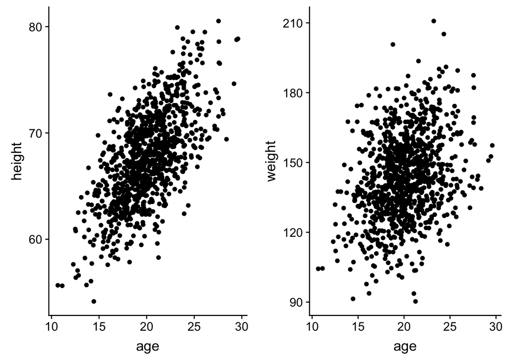

```r
HeightVsAge <- ggplot(d, aes(x=age, y=height)) +
                        geom_point()

WeightVsAge <- ggplot(d, aes(x=age, y=weight)) +
                  geom_point()

plot_grid(HeightVsAge, WeightVsAge)
```

```r
# Both of these variables seem to have a positive correlation with age.
```

#### 2.d. Using histograms and Q-Q plots, check whether the quantitative variables seem to be drawn from a normal distribution. Which seem to be and which do not?

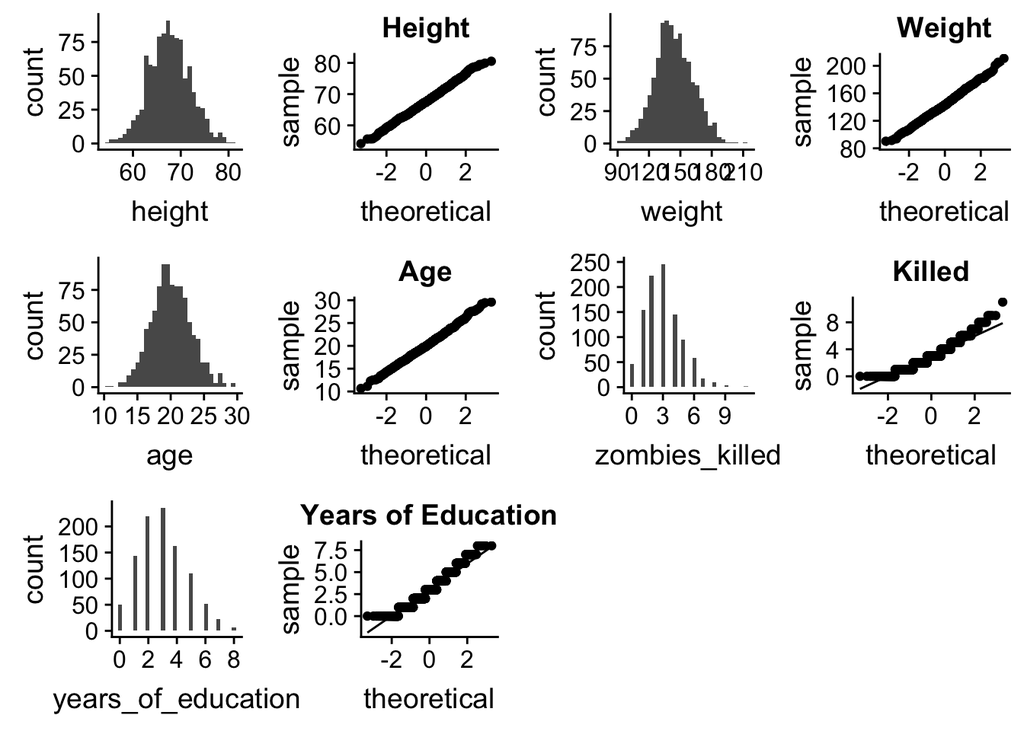

```r
hist.height <- ggplot(d, aes(x=height)) +
  geom_histogram()

hist.weight <- ggplot(d, aes(x=weight)) +
  geom_histogram()

hist.age <- ggplot(d, aes(x=age)) +
  geom_histogram()

hist.killed <- ggplot(d, aes(x=zombies_killed)) +
  geom_histogram()

hist.ed <- ggplot(d, aes(x=years_of_education)) +
  geom_histogram()

qq.height <- ggplot(d, aes(sample=height)) +
  geom_qq() +
  geom_qq_line() +
  ggtitle("Height")

qq.weight <- ggplot(d, aes(sample=weight)) +
  geom_qq() +
  geom_qq_line() +
  ggtitle("Weight")

qq.age <- ggplot(d, aes(sample=age)) +
  geom_qq() +
  geom_qq_line() +
  ggtitle("Age")

qq.killed <- ggplot(d, aes(sample=zombies_killed)) +
  geom_qq() +
  geom_qq_line() +
  ggtitle("Killed")

qq.ed <- ggplot(d, aes(sample=years_of_education)) +
  geom_qq() +
  geom_qq_line() +
  ggtitle("Years of Education")


plot_grid(hist.height, qq.height, hist.weight, qq.weight, hist.age, qq.age, hist.killed, qq.killed, hist.ed, qq.ed)
```

```r
# Height, weight, and age appear to be normally distributed. zombies_killed, and years_of_education appear not to be normally distributed.
```